# Homeless Dataset Regression Model 2 - Poisson Regression Model

### Plot the coefficient

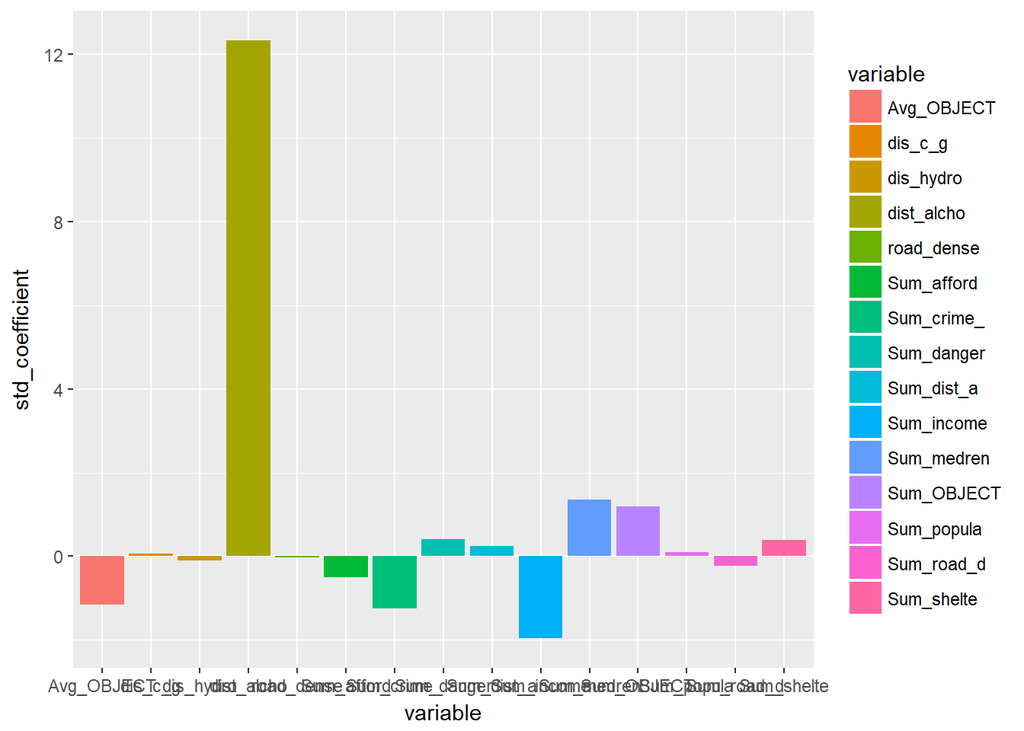

####Absolute value of coefficients (easy to visuliz and compare)

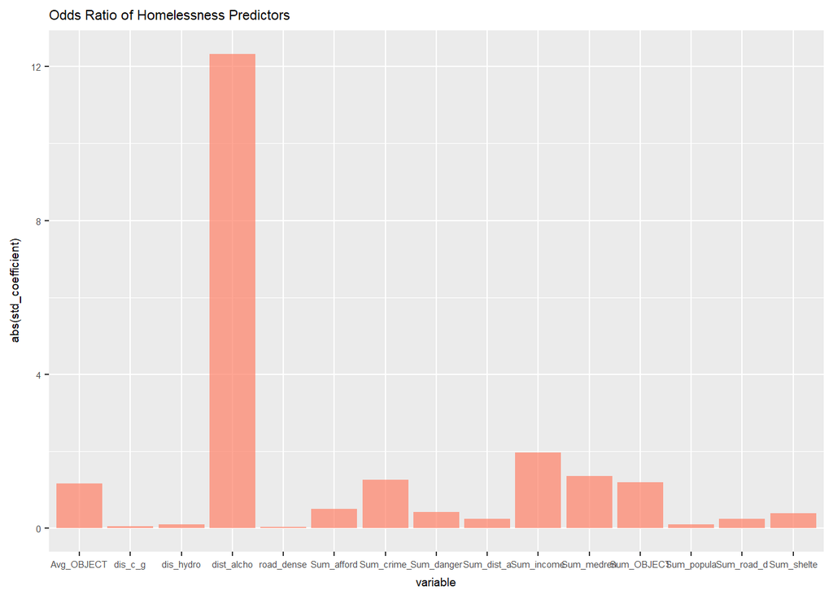

####Reordering the Histogram by magnitude

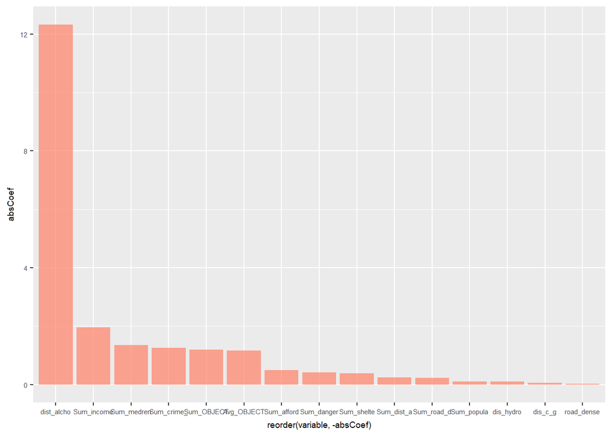

From the absolute value table we can see that the varaible with highest coefficient value is the “distance to alchoel store”, the second high coefficient value is “the average income level per census tracts”

What the meaning of the fitted values? The highest percentage cells have expected rate of “have a homeless shelter” is 9.7 times higher than the cell that have value of “1.00708”

```
## [1] 1.007083 9.707446
```